# Spatial Coherence Length and the 1/f Spectrum Falloff

This script illustrates how a finite spatial coherence length creates the empirical 1/f^\alpha contrast falloff across viewing distances.

In natural scenes, the contrast modulation and phase of texture patterns rarely hold over an infinite extent. Instead, patterns maintain consistent frequency and phase over a characteristic number of cycles (N_c around 3 to 5). Consequently, the spatial coherence length in space is inversely related to spatial frequency:

When an observer views a surface pattern from varying distances:

- **Close distance (d = 0.25)**: The field of view captures only a few cycles (~N_c). The pattern is coherent across the aperture, concentrating its contrast into a sharp, high-amplitude Fourier peak.
- **Far distance (d = 1.00)**: The field of view captures many cycles (>> N_c). Random phase drift across the broader aperture disperses spectral energy across adjacent frequencies, reducing the measured peak amplitude.

By Parseval's theorem, preserving constant physical surface contrast means that spectral broadening directly reduces peak Fourier amplitude, yielding the empirical power-law falloff:

**Note on 1D vs. 2D scaling**: In a 1D aperture of width W, summing M independent random-phase patches yields coherent amplitude \sqrt{M}, giving 1D amplitude falloff:

(\alpha between 0.5 and 0.7). In 2D, area scaling (W^2) yields M \propto f^2, giving 2D amplitude falloff:

(\alpha = 1.0), which corresponds to the classic 2D power spectrum P(f) \propto 1/f^2.

See also: `iePublish`, `gaborWaveletSVG`, `ieFigure`

## Contents

- 1. Control flags and parameters
- 2. Generate surface pattern with constant-Q spatial coherence
- 3. Extract waveforms at each viewing distance (fixed FOV)
- 4. Plot 1: Spatial waveforms across viewing distances
- 5. Plot 2: Fourier spectra & 1/f^alpha falloff in visual angle
- 6. Print summary table to console

## 1. Control flags and parameters

```matlab
saveSVG = false;  % Set to true when ready to export SVGs for Affinity Designer

% Random draw control
rng(10); % Seed 10 gives clean waveforms and a clear monotonic drop

% Coherence parameters
nCyclesCoherent = 5;    % Coherence length in cycles (3 to 5)
alpha           = 0.5;  % Falloff exponent: A(f) = C / f^alpha

% Carrier frequency across the full physical domain (far view, d = 1.0)
fCarrier = 10;

% Bandwidth for constant-Q coherence: sigma_f = fCarrier / nCyclesCoherent
sigma_f = fCarrier / nCyclesCoherent;

% Viewing distances (relative to full extent)
distances  = [0.25, 0.50, 1.00];
distColors = [
    0.90 0.45 0.10;   % Close (d = 0.25)
    0.20 0.60 0.80;   % Medium (d = 0.50)
    0.20 0.20 0.20    % Far (d = 1.00)
];

nSamples = 4000;
```

## 2. Generate surface pattern with constant-Q spatial coherence

```matlab
whiteNoise = randn(1, nSamples);
W = fft(whiteNoise);
f = [0:(nSamples/2), -(nSamples/2 - 1):-1];

% Gaussian bandpass filter centered at +/- fCarrier with bandwidth sigma_f
H = exp(-0.5 * ((abs(f) - fCarrier) / sigma_f).^2);
yFull = real(ifft(W .* H));
yFull = yFull / std(yFull); % Constant physical surface contrast
```

## 3. Extract waveforms at each viewing distance (fixed FOV)

```matlab
nDist     = length(distances);
waveforms = cell(nDist, 1);
spectra   = cell(nDist, 1);
peakFreq  = zeros(nDist, 1);
peakAmp   = zeros(nDist, 1);

freqAxis = linspace(0, nSamples/2, nSamples/2 + 1);

for ii = 1:nDist
    d = distances(ii);

    % Central window on the surface intercepted by the eye's field of view
    nWin = round(nSamples * d);
    startIdx = round((nSamples - nWin)/2) + 1;
    idx = startIdx : (startIdx + nWin - 1);
    yw = yFull(idx);

    % Resample across the fixed angular field of view
    yFOV = interp1(linspace(0, 1, length(yw)), yw, linspace(0, 1, nSamples));

    % Crucial: Normalizing to unit RMS contrast (physical contrast is distance-invariant)
    yFOV = yFOV / std(yFOV);
    waveforms{ii} = yFOV;

    % One-sided Fourier amplitude spectrum
    Y = abs(fft(yFOV)) / nSamples;
    Y_onesided = 2 * Y(1:nSamples/2 + 1);
    spectra{ii} = Y_onesided;

    % Find carrier peak (excluding DC bin)
    [peakAmp(ii), maxIdx] = max(Y_onesided(2:40));
    peakFreq(ii) = freqAxis(maxIdx + 1);
end
```

## 4. Plot 1: Spatial waveforms across viewing distances

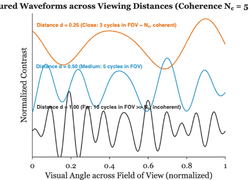

```matlab
hWave = ieFigure;
hold on;
labels = {
    sprintf('Distance d = 0.25 (Close: %d cycles in FOV ~ N_c, coherent)', round(fCarrier*distances(1))), ...
    sprintf('Distance d = 0.50 (Medium: %d cycles in FOV)', round(fCarrier*distances(2))), ...
    sprintf('Distance d = 1.00 (Far: %d cycles in FOV >> N_c, incoherent)', round(fCarrier*distances(3)))
};

for ii = 1:nDist
    offset = (nDist - ii) * 2.8;
    plot(linspace(0, 1, nSamples), waveforms{ii} + offset, ...
        'Color', distColors(ii, :), 'LineWidth', 1.8);
    text(0.02, offset + 1.4, labels{ii}, ...
        'FontSize', 11, 'FontWeight', 'bold', 'Color', distColors(ii, :));
end
hold off;
ylim([-2.0, (nDist - 1) * 2.8 + 2.2]);
xlim([0, 1]);
xlabel('Visual Angle across Field of View (normalized)');
ylabel('Normalized Contrast');
title(sprintf('Captured Waveforms across Viewing Distances (Coherence N_c = %d cycles)', nCyclesCoherent));
set(gca, 'YTick', []);

if saveSVG
    print(hWave, 'coherence_waveforms_multi_distance.svg', '-dsvg');
end
```

## 5. Plot 2: Fourier spectra & 1/f^alpha falloff in visual angle

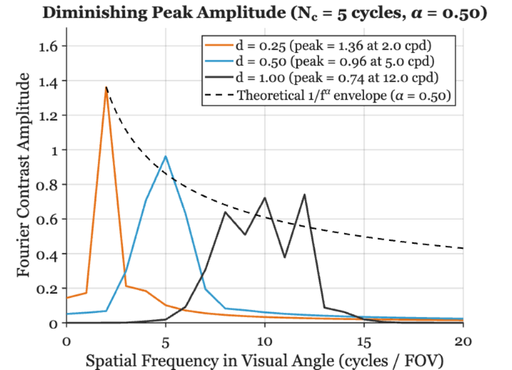

```matlab
hSpec = ieFigure;
hold on;
legEntries = cell(nDist, 1);
for ii = 1:nDist
    plot(freqAxis, spectra{ii}, 'Color', distColors(ii, :), 'LineWidth', 2);
    legEntries{ii} = sprintf('d = %.2f (peak = %.2f at %.1f cpd)', ...
        distances(ii), peakAmp(ii), peakFreq(ii));
end

% Overlay the 1/f^alpha reference curve anchored at the closest peak:
% A(f) = A_1 * (f_1 / f)^alpha
fFit = linspace(peakFreq(1), 2 * fCarrier, 200);
curve1overF = peakAmp(1) * (peakFreq(1) ./ fFit).^alpha;

plot(fFit, curve1overF, 'k--', 'LineWidth', 1.5);
if alpha == 1
    legEntries{end+1} = 'Theoretical 1/f envelope (C/f)';
else
    legEntries{end+1} = sprintf('Theoretical 1/f^\\alpha envelope (\\alpha = %.2f)', alpha);
end

hold off;
xlim([0, 2 * fCarrier]); % x-axis limit set to 2x carrier frequency
ylim([0, max(peakAmp) * 1.25]);
xlabel('Spatial Frequency in Visual Angle (cycles / FOV)');
ylabel('Fourier Contrast Amplitude');
title(sprintf('Diminishing Peak Amplitude (N_c = %d cycles, \\alpha = %.2f)', nCyclesCoherent, alpha));
legend(legEntries, 'Location', 'northeast');
grid on;

if saveSVG
    print(hSpec, 'coherence_spectra_multi_distance.svg', '-dsvg');
end
```

## 6. Print summary table to console

```matlab
fprintf('\n--- Coherence (N_c = %d cycles) & 1/f Summary ---\n', nCyclesCoherent);
for ii = 1:nDist
    fprintf('Distance: %.2f | Peak Frequency: %4.1f cyc/FOV | Peak Amplitude: %5.3f\n', ...
        distances(ii), peakFreq(ii), peakAmp(ii));
end
fprintf('---------------------------------------------------\n');
```

```
--- Coherence (N_c = 5 cycles) & 1/f Summary ---
Distance: 0.25 | Peak Frequency:  2.0 cyc/FOV | Peak Amplitude: 1.363
Distance: 0.50 | Peak Frequency:  5.0 cyc/FOV | Peak Amplitude: 0.963
Distance: 1.00 | Peak Frequency: 12.0 cyc/FOV | Peak Amplitude: 0.742
---------------------------------------------------
```

[Published with MATLAB® R2026a](https://www.mathworks.com/products/matlab/)